# Introduction to R: Exploring the tidyverse

## Introduction

This workshop is designed to provide beginners with foundational understanding of R programming language. Through a combination of theoretical explanations, hands-on coding exercises, and practical applications, participants will learn how to leverage R for data analysis, manipulation and visualization cancer biology datasets.

The workshop will cover essential programming concepts and gradually introduce more advanced topics, with a focus on using the tidyverse package suite for efficient data handling, analysis and visualization. The aim of this workshop is to improve the reproducibility and efficiency of scientific research by teaching powerful tools in data analysis and creating informative plots.

## Learning Objectives

Participants will gain the following skills:

- Proficiency in using R and RStudio for data analysis.
- Basic R programming skills.
- Reading, tidying, and joining datasets using `readr` and `tidyr` packages.
- Data manipulation and transformation using `dplyr` package.
- Creating various types of plots using `ggplot2` package.

## Prerequisites

Before starting this course you will need to ensure that your computer is set up with the required software. If you have any difficulty installing any of this software then please contact one of the trainers for help.

### Installing R and RStudio

**R** and **RStudio** are separate downloads and installations.

**R** is the underlying statistical computing environment. The base R system and a very large collection of packages that give you access to a huge range of statistical and analytical functionality are available from [CRAN](https://cran.r-project.org), the Comprehensive R Archive Network.

However, using R alone is no fun. **RStudio** is a graphical integrated development environment (IDE) that makes using R much easier and more interactive.

#### Option 1: Local Installation

You need to install R before you install RStudio.

**Windows**

- **If you already have R and RStudio installed:**
  - Open RStudio, and click on “Help” > “Check for updates”. If a new version is available, quit RStudio, and download the latest version for RStudio.
  - To check which version of R you are using, start RStudio and the first thing that appears in the console indicates the version of R you are running. Alternatively, you can type `sessionInfo()`, which will also display which version of R you are running. Go on the [CRAN website](https://cran.r-project.org/bin/windows/base/) and check whether a more recent version is available. If so, please download and install it. You can [check here](https://cran.r-project.org/bin/windows/base/rw-FAQ.html#How-do-I-UNinstall-R_003f) for more information on how to remove old versions from your system if you wish to do so.
- **If you don’t have R and RStudio installed:**
  - Download R from the [CRAN website](https://cran.r-project.org/bin/windows/base/release.htm).
  - Run the `.exe` file that was just downloaded
  - Go to the [RStudio download page](https://www.rstudio.com/products/rstudio/download/#download)
  - Under *Installers* select **RStudio x.yy.zzz - Windows 10/8/7** where x, y, and z represent version numbers)
  - Double click the file to install it
  - Once it’s installed, open RStudio to make sure it works and you don’t get any error messages.

**macOS**

- **If you already have R and RStudio installed:**
  - Open RStudio, and click on “Help” > “Check for updates”. If a new version is available, quit RStudio, and download the latest version for RStudio.
  - To check the version of R you are using, start RStudio and the first thing that appears on the terminal indicates the version of R you are running. Alternatively, you can type `sessionInfo()`, which will also display which version of R you are running. Go on the [CRAN website](https://cran.r-project.org/bin/macosx/) and check whether a more recent version is available. If so, please download and install it.
- **If you don’t have R and RStudio installed:**
  - Download R from the [CRAN website](https://cran.r-project.org/bin/macosx/).
  - Select the `.pkg` file for the latest R version
  - Double click on the downloaded file to install R
  - It is also a good idea to install [XQuartz](https://www.xquartz.org/) (needed by some packages)
  - Go to the [RStudio download page](https://www.rstudio.com/products/rstudio/download/#download)
  - Under *Installers* select **RStudio x.yy.zzz - Mac OS X 10.6+ (64-bit)** (where x, y, and z represent version numbers)
  - Double click the file to install RStudio
  - Once it’s installed, open RStudio to make sure it works and you don’t get any error messages.

**Linux**

- Follow the instructions for your distribution from [CRAN](https://cloud.r-project.org/bin/linux), they provide information to get the most recent version of R for common distributions. For most distributions, you could use your package manager (e.g., for Debian/Ubuntu run `sudo apt-get install r-base`, and for Fedora `sudo yum install R`), but we don’t recommend this approach as the versions provided by this are usually out of date. In any case, make sure you have at least R 4.3.2.
- Go to the [RStudio download page](https://www.rstudio.com/products/rstudio/download/#download)
- Under *Installers* select the version that matches your distribution, and install it with your preferred method (e.g., with Debian/Ubuntu `sudo dpkg -i rstudio-x.yy.zzz-amd64.deb` at the terminal).
- Once it’s installed, open RStudio to make sure it works and you don’t get any error messages.

#### Option 2: Using Open On Demand on Peter Mac Cluster

**Requesting Access to Peter Mac Cluster**

To request access to the Cluster

1. Login to [SNOW](https://rchauprod.service-now.com/snow?id=pmcc_home) and create an IT Service Desk Request as shown [here](https://confluence.petermac.org.au/pages/viewpage.action?pageId=161024525).
2. Complete the required fields, including the following information.
- **Request Item:** (Other)
- **Service:** Research Computing Cluster
- **Subject:** HPC Cluster Account for $first_name $last_name
- **Description:** Please include the name of the person who needs the account, their lab group, their manager or supervisor and what experience they have with using a HPC cluster (e.g. none, some, experienced).

**Using Open On Demand**

**Open OnDemand** is a web portal that provides access to PeterMac file systems and cluster resources. It allows to view, edit, upload and download files, create, edit, submit and monitor jobs, run GUI applications, and connect via SSH, all via a web browser and with a minimal knowledge of Linux and scheduler commands. It enables running RStudio on the cluster giving you access to more memory than with our RStudio Pro server. Future work will enable it to use Jupyter notebooks on the cluster.

**How to login**

Requirements:

- Must have a cluster account.
- If want to use remotely:
  - Must have remote access to Citrix or VPN.
  - With Citrix must use Peter Mac Virtual Desktop and the Firefox inside that.
- Username: your short cluster username not your Peter Mac computer username (i.e., first_letter_of_first_namelast_name ex: srajapaksa NOT last_namefirst_name ex: rajapaksasandun)
- Password: Peter Mac cluster password.

In a browser navigate to https://research-cluster.petermac.org.au and enter your login, as in:

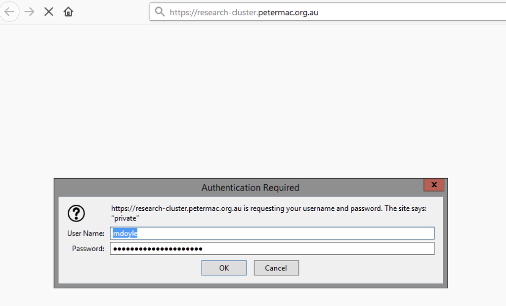

If you see the following Unauthorized error instead of the login prompt, you will need to use the Citrix Edge Browser.

[figure not shown]

You should then see in the Open OnDemand Dashboard as in:

[figure not shown]

### Installing R Packages

On this course we will be making use of a brilliant collection of packages designed for data science called the **`tidyverse`** that make it much easier and more fun to work with your data. After installing R and RStudio, follow the instructions below to install the `tidyverse` package suite.

- After starting RStudio, at the console type: `install.packages("tidyverse")` (look for the ‘Console’ tab and type at the `>` prompt)
- You can also do this by going to Tools -> Install Packages and typing the names of the packages separated by a comma.

## Data

The Metabric study characterized the genomic mutations and gene expression profiles for 2509 primary breast tumours. In addition to the gene expression data generated using microarrays, genome-wide copy number profiles were obtained using SNP microarrays. Targeted sequencing was performed for 2509 primary breast tumours, along with 548 matched normals, using a panel of 173 of the most frequently mutated breast cancer genes as part of the Metabric study.

**Refrences:**

- [Curtis *et al.*, Nature 486:346-52, 2012](https://pubmed.ncbi.nlm.nih.gov/22522925)
- [Pereira *et al.*, Nature Communications 7:11479, 2016](https://www.ncbi.nlm.nih.gov/pubmed/27161491)

Both the clinical data and the gene expression values were downloaded from [cBioPortal](https://www.cbioportal.org/study/summary?id=brca_metabric).

We excluded observations for patient tumor samples lacking expression data, resulting in a data set with fewer rows.

## Into the tidyverse

The core tidyverse includes the packages that you’re likely to use in everyday data analyses. Therefore, this workshop offers an introduction to these core packages. As of tidyverse 1.3.0, the following packages are included in the core tidyverse:

[figure not shown]

Figure 1: Hex logos for the eight core tidyverse packages and their primary purposes. Image source:https://education.rstudio.com/blog/2020/07/teaching-the-tidyverse-in-2020-part-1-getting-started/

- [**ggplot2**](https://ggplot2.tidyverse.org/): *Grammar of Graphics.* Enables the creation of graphics in a declarative manner.
- [**dplyr**](https://dplyr.tidyverse.org/): *Grammar for data manipulation*. Presents a set of verbs to address common challenges in data manipulation.
- [**tidyr**](https://tidyr.tidyverse.org/): Provides a collection of functions for achieving tidy data.
- [**readr**](https://readr.tidyverse.org/): Facilitates the rapid and user-friendly reading of rectangular data (e.g., csv, tsv, and fwf).
- [**purrr**](https://purrr.tidyverse.org/): *Functional programming toolkit.* Offers a set of tools for efficient work with functions and vectors.
- [**tibble**](https://tibble.tidyverse.org/): *Tibbles*, a modern re-imagining of the data frame, offering a more user-friendly and efficient approach to handling tabular data.
- [**stringr**](https://stringr.tidyverse.org/): Provides a set of functions designed to simplify and enhance string manipulations.
- [**forcats**](https://forcats.tidyverse.org/): Provides a suite of useful tools for handling and manipulating categorical variables (*factors*).

## Credits and Acknowledgement

These content were adapted from the following course materials:

- [R for Data Science book](https://r4ds.had.co.nz/index.html)
- [OHI Data Science Training](http://ohi-science.org/data-science-training/index.html)
- [Data Carpentry](https://datacarpentry.org)
- [WEHI tidyr coursebook](https://bookdown.org/ansellbr/WEHI_tidyR_course_book/) by Brendan R. E. Ansell
- content developed by Maria Doyle.